# Exploring the NOAA Storm Database and analysing severe weather events

Ananya Mantravadi

26/08/2020

## Synopsis

Storms and other severe weather events can cause both public health and economic problems for communities and municipalities. Many severe events can result in fatalities, injuries, and property damage, and preventing such outcomes to the extent possible is a key concern.

This project involves exploring the U.S. National Oceanic and Atmospheric Administration’s (NOAA) storm database. This database tracks characteristics of major storms and weather events in the United States, including when and where they occur, as well as estimates of any fatalities, injuries, and property damage.

This report is an attempt to answering the following questions:  
1. Across the United States, which types of weather events are most harmful with respect to population health?  
2. Across the United States, which types of weather events have the most severe economic consequences health?

## Loading Packages and Data Processing

```r
knitr::opts_chunk$set(echo = TRUE, message = FALSE)
```

```r
library(ggplot2)
library(dplyr)
```

The first work to perform is to unzip the file and to read the csv while assigning it to a variable name “data”.Then display head of the data.

```r
#Downloaded file from "https://d396qusza40orc.cloudfront.net/repdata%2Fdata%2FStormData.csv.bz2" and renamed the file StormData.csv after zipping
data<-read.csv("StormData.csv")
head(data,3)
```

```
##   STATE__          BGN_DATE BGN_TIME TIME_ZONE COUNTY COUNTYNAME STATE  EVTYPE
## 1       1 4/18/1950 0:00:00     0130       CST     97     MOBILE    AL TORNADO
## 2       1 4/18/1950 0:00:00     0145       CST      3    BALDWIN    AL TORNADO
## 3       1 2/20/1951 0:00:00     1600       CST     57    FAYETTE    AL TORNADO
##   BGN_RANGE BGN_AZI BGN_LOCATI END_DATE END_TIME COUNTY_END COUNTYENDN
## 1         0                                               0         NA
## 2         0                                               0         NA
## 3         0                                               0         NA
##   END_RANGE END_AZI END_LOCATI LENGTH WIDTH F MAG FATALITIES INJURIES PROPDMG
## 1         0                      14.0   100 3   0          0       15    25.0
## 2         0                       2.0   150 2   0          0        0     2.5
## 3         0                       0.1   123 2   0          0        2    25.0
##   PROPDMGEXP CROPDMG CROPDMGEXP WFO STATEOFFIC ZONENAMES LATITUDE LONGITUDE
## 1          K       0                                         3040      8812
## 2          K       0                                         3042      8755
## 3          K       0                                         3340      8742
##   LATITUDE_E LONGITUDE_ REMARKS REFNUM
## 1       3051       8806              1
## 2          0          0              2
## 3          0          0              3
```

The total number of rows is 902297 and the total number of columns is 37. Subset the data and select only those columns that are useful for the analysis.

```r
data=data[,c('EVTYPE','FATALITIES','INJURIES', 'PROPDMG', 'PROPDMGEXP', 'CROPDMG', 'CROPDMGEXP')]
table(data$PROPDMGEXP)
```

```
##
##             -      ?      +      0      1      2      3      4      5      6
## 465934      1      8      5    216     25     13      4      4     28      4
##      7      8      B      h      H      K      m      M
##      5      1     40      1      6 424665      7  11330
```

From the documentation, we understand the following mapping in the variable “PROPDMGEXP”:

```r
data$PROPDMGEXP2 <- 1
data$PROPDMGEXP2[which(data$PROPDMGEXP == "1" | data$PROPDMGEXP == "2"| data$PROPDMGEXP == "3"| data$PROPDMGEXP == "4"| data$PROPDMGEXP == "5"| data$PROPDMGEXP == "6"| data$PROPDMGEXP == "7"| data$PROPDMGEXP == "8"| data$PROPDMGEXP == "9")] <- 10
data$PROPDMGEXP2[which(data$PROPDMGEXP == "H" | data$PROPDMGEXP == "h")] <- 100
data$PROPDMGEXP2[which(data$PROPDMGEXP == "K")] <- 1000
data$PROPDMGEXP2[which(data$PROPDMGEXP == "M" | data$PROPDMGEXP == "m")] <- 1000000
data$PROPDMGEXP2[which(data$PROPDMGEXP == "B")] <- 1000000000
table(data$PROPDMGEXP2)
```

```
##
##      1     10    100   1000  1e+06  1e+09
## 466164     84      7 424665  11337     40
```

## Results

### Across the United States, which types of weather events are most harmful with respect to population health?

The first plot gives us the most harmful weather events with respect to fatalities occurred.

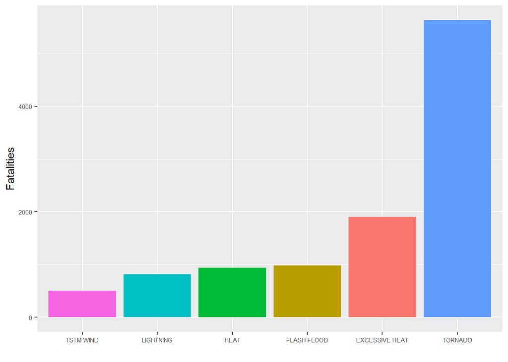

```r
data %>%
      select(FATALITIES, EVTYPE) %>%
      group_by(EVTYPE) %>%
      summarise(SumFATALITIES = sum(FATALITIES)) %>%
      top_n(n = 6, wt = SumFATALITIES) %>%
      ggplot(aes(y = SumFATALITIES, x = reorder(x = EVTYPE, X = SumFATALITIES), fill=EVTYPE)) +
      geom_bar(stat = "identity", show.legend = FALSE) +
      xlab(label = "") + ylab(label = "Fatalities") +
      theme(axis.text = element_text(size = 6))
```

The second plot gives us the most harmful weather events with respect to injuries.

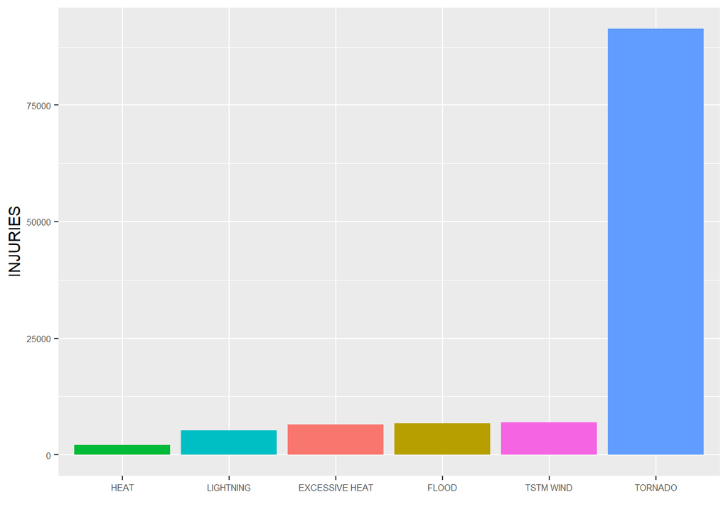

```r
data %>%
      select(INJURIES, EVTYPE) %>%
      group_by(EVTYPE) %>%
      summarise(SumINJURIES = sum(INJURIES)) %>%
      top_n(n = 6, wt = SumINJURIES) %>%
      ggplot(aes(y = SumINJURIES, x = reorder(x = EVTYPE, X = SumINJURIES), fill=EVTYPE)) +
      geom_bar(stat = "identity", show.legend = FALSE) +
      xlab(label = "") +
      ylab(label = "INJURIES") +
      theme(axis.text = element_text(size = 6))
```

### Across the United States, which types of weather events have the most severe economic consequences health?

The following plot gives us the most harmful weather events with respect to property damage estimates.

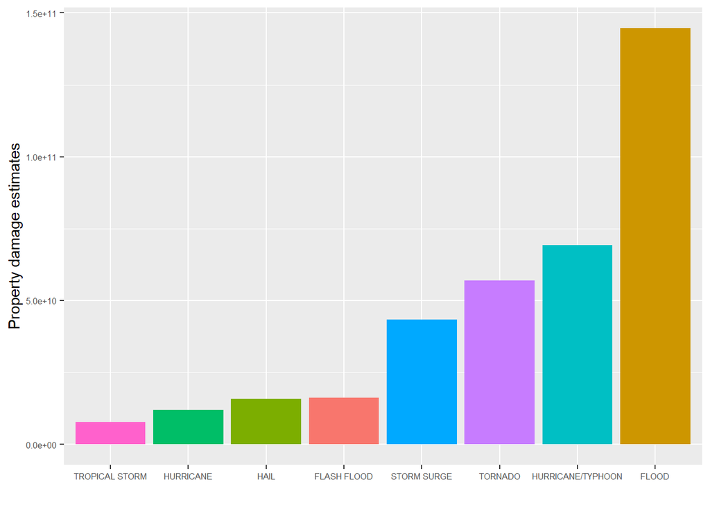

```r
data %>%
      select(PROPDMG, PROPDMGEXP2, EVTYPE) %>%
      group_by(EVTYPE) %>%
      mutate(SumPROPDMGEXP = (PROPDMG * PROPDMGEXP2)) %>%
      summarise(SumPROPDMGEXP2 = sum(SumPROPDMGEXP)) %>%
      top_n(n = 8, wt = SumPROPDMGEXP2) %>%
      ggplot(aes(y = SumPROPDMGEXP2, x = reorder(x = EVTYPE, X = SumPROPDMGEXP2), fill=EVTYPE))+
      geom_bar(stat = "identity", show.legend = FALSE) +
      xlab(label = "") +
      ylab(label = "Property damage estimates") +
      theme(axis.text = element_text(size = 6))
```

## Conclusion

It is observed in above analysis that Flood has the greatest economic consequences whereas Tornado is the most harmful to population health because it caused the most fatalities and injuries.